# EjerciciosA2

Felipe Yebes

2023-11-05

```r
if( !require(faraway)){ install.packages('faraway', dependencies = TRUE)}
if( !require(tydiverse)){ install.packages('tidyverse', dependencies = TRUE)}
if( !require(plotly)){install.packages('plotly', dependencies = TRUE)}
if(!require(GGally)){install.packages("GGally", dependencies = TRUE)}
if(!require(psych)){install.packages('psych', dependencies = TRUE)}
library("gridExtra", "grid")
library("ggplot2")
```

## Ejercicios del libro de Faraway

1. Ejercicio 1 cap.2 pag.30
   1. What percentage of variation in the reponse is explained by these predictors?

   En los ejercicios anteriores se realizó un análisis gráfico de los datos que se reproduce aquí.

   ```r
   data(teengamb,package="faraway")
   head(teengamb)
   ```

   ```
   ##   sex status income verbal gamble
   ## 1   1     51   2.00      8    0.0
   ## 2   1     28   2.50      8    0.0
   ## 3   1     37   2.00      6    0.0
   ## 4   1     28   7.00      4    7.3
   ## 5   1     65   2.00      8   19.6
   ## 6   1     61   3.47      6    0.1
   ```

   ```r
   summary(teengamb)
   ```

   ```
   ##       sex             status          income           verbal
   ##  Min.   :0.0000   Min.   :18.00   Min.   : 0.600   Min.   : 1.00
   ##  1st Qu.:0.0000   1st Qu.:28.00   1st Qu.: 2.000   1st Qu.: 6.00
   ##  Median :0.0000   Median :43.00   Median : 3.250   Median : 7.00
   ##  Mean   :0.4043   Mean   :45.23   Mean   : 4.642   Mean   : 6.66
   ##  3rd Qu.:1.0000   3rd Qu.:61.50   3rd Qu.: 6.210   3rd Qu.: 8.00
   ##  Max.   :1.0000   Max.   :75.00   Max.   :15.000   Max.   :10.00
   ##      gamble
   ##  Min.   :  0.0
   ##  1st Qu.:  1.1
   ##  Median :  6.0
   ##  Mean   : 19.3
   ##  3rd Qu.: 19.4
   ##  Max.   :156.0
   ```

   Tal y como aparece en el estudio la variable sexo se debería convertir a factor, la variable status se refiere una puntuación que valora el estatus socioeconómico de los padres en relación a su ocupación, income son los ingresos semanales, verbal es la puntuación en un test verbal y gamble son los gastos en juegos de azar.

   En el resumen, salvo en el sexo y en gastos no parece haber datos con valores de 0, aunque son bastante lógicos, sería necesario comprobar el numero de valores faltantes.

   ```r
   apply(X = is.na(teengamb), MARGIN = 2, FUN = sum)
   ```

   ```
   ##    sex status income verbal gamble
   ##      0      0      0      0      0
   ```

   Vemos que no hay valores faltantes y que los valores numéricos son hasta cierto punto coherentes.

   Se convierte en factor el parámetro sexo y se adjudican niveles

   ```r
   teengamb$sex<-factor(teengamb$sex)
   levels(teengamb$sex)<-c("Masc","Fem")
   teengamb$sex
   ```

   ```
   ##  [1] Fem  Fem  Fem  Fem  Fem  Fem  Fem  Fem  Fem  Fem  Fem  Fem  Fem  Fem  Fem
   ## [16] Fem  Fem  Fem  Fem  Masc Masc Masc Masc Masc Masc Masc Masc Masc Masc Masc
   ## [31] Masc Masc Masc Masc Masc Masc Masc Masc Masc Masc Masc Masc Masc Masc Masc
   ## [46] Masc Masc
   ## Levels: Masc Fem
   ```

   ```r
   summary(teengamb)
   ```

   ```
   ##    sex         status          income           verbal          gamble
   ##  Masc:28   Min.   :18.00   Min.   : 0.600   Min.   : 1.00   Min.   :  0.0
   ##  Fem :19   1st Qu.:28.00   1st Qu.: 2.000   1st Qu.: 6.00   1st Qu.:  1.1
   ##            Median :43.00   Median : 3.250   Median : 7.00   Median :  6.0
   ##            Mean   :45.23   Mean   : 4.642   Mean   : 6.66   Mean   : 19.3
   ##            3rd Qu.:61.50   3rd Qu.: 6.210   3rd Qu.: 8.00   3rd Qu.: 19.4
   ##            Max.   :75.00   Max.   :15.000   Max.   :10.00   Max.   :156.0
   ```

   Estudio gráfico

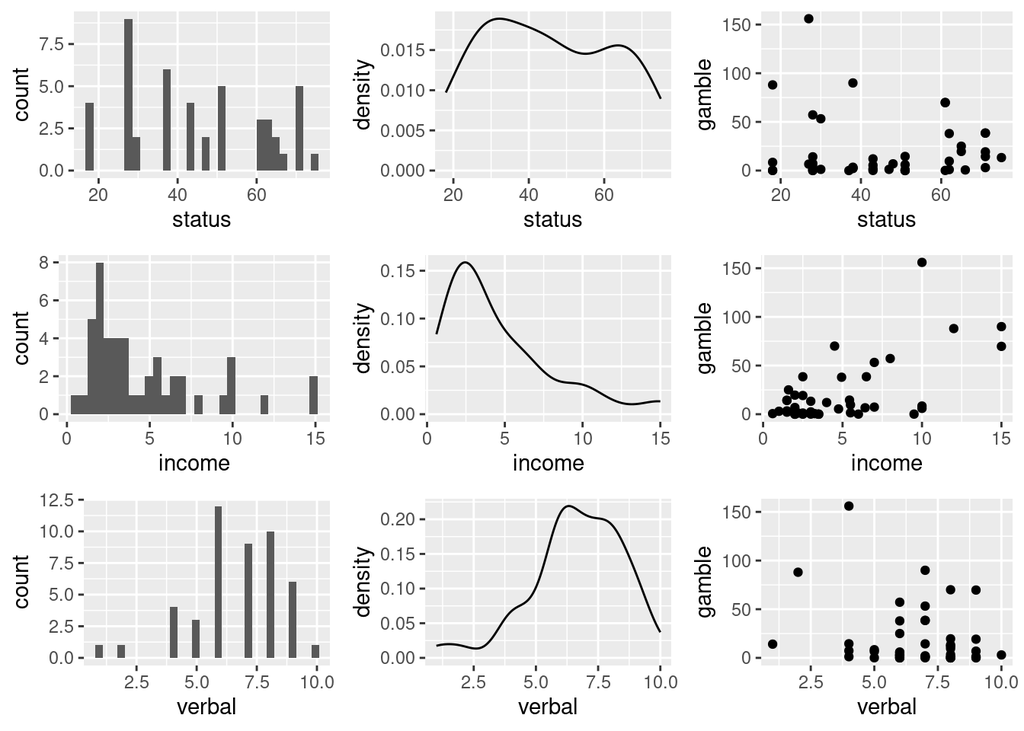

   ```r
   g1<-ggplot(teengamb,aes(x=status))+geom_histogram(bins = 30)
   g2<-ggplot(teengamb,aes(x=status))+geom_density()
   g3<-ggplot(teengamb,aes(x=status,y=gamble))+geom_point()
   g4<-ggplot(teengamb,aes(x=income))+geom_histogram(bins = 30)
   g5<-ggplot(teengamb,aes(x=income))+geom_density()
   g6<-ggplot(teengamb,aes(x=income,y=gamble))+geom_point()
   g7<-ggplot(teengamb,aes(x=verbal))+geom_histogram(bins = 30)
   g8<-ggplot(teengamb,aes(x=verbal))+geom_density()
   g9<-ggplot(teengamb,aes(x=verbal,y=gamble))+geom_point()
   grid.arrange(g1,g2,g3,g4,g5,g6,g7,g8,g9, ncol = 3)
   ```

Se realiza ahora gráfica tipo scarlett plot matrix con el paquete gráfico base y con GGally

[figure not shown]

```r
pairs(teengamb[,2:4],col = "green",labels = c("Estatus", "Ingresos", "Gastos"), main = "Este es un gráfico scarlett con el paquete básico")
```

Con GGally

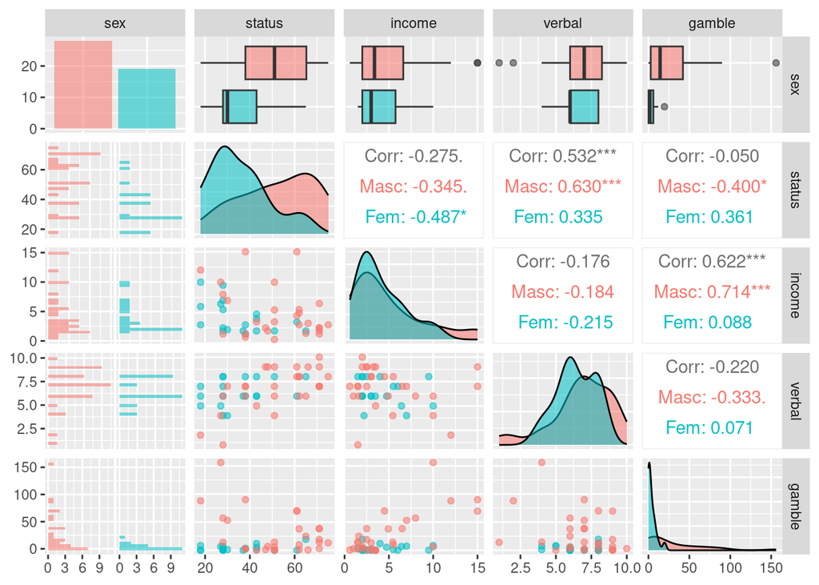

```r
library(GGally)
ggpairs(teengamb, aes(colour = sex, alpha = 0.4))
```

Parece que las mayores correlaciones con la variable respuesta o dependiente se dan en el parámetro ingreso. De todas maneras se realiza un modelo en el que están incluidas todas la variables

```r
modelolineal<-lm(gamble~sex+status+income+verbal,data=teengamb)
summary(modelolineal)
```

```
##
## Call:
## lm(formula = gamble ~ sex + status + income + verbal, data = teengamb)
##
## Residuals:
##     Min      1Q  Median      3Q     Max
## -51.082 -11.320  -1.451   9.452  94.252
##
## Coefficients:
##              Estimate Std. Error t value Pr(>|t|)
## (Intercept)  22.55565   17.19680   1.312   0.1968
## sexFem      -22.11833    8.21111  -2.694   0.0101 *
## status        0.05223    0.28111   0.186   0.8535
## income        4.96198    1.02539   4.839 1.79e-05 ***
## verbal       -2.95949    2.17215  -1.362   0.1803
## ---
## Signif. codes:  0 '***' 0.001 '**' 0.01 '*' 0.05 '.' 0.1 ' ' 1
##
## Residual standard error: 22.69 on 42 degrees of freedom
## Multiple R-squared:  0.5267, Adjusted R-squared:  0.4816
## F-statistic: 11.69 on 4 and 42 DF,  p-value: 1.815e-06
```

Se realiza un primer estudio gráfico para comprobar los supuestos del modelo

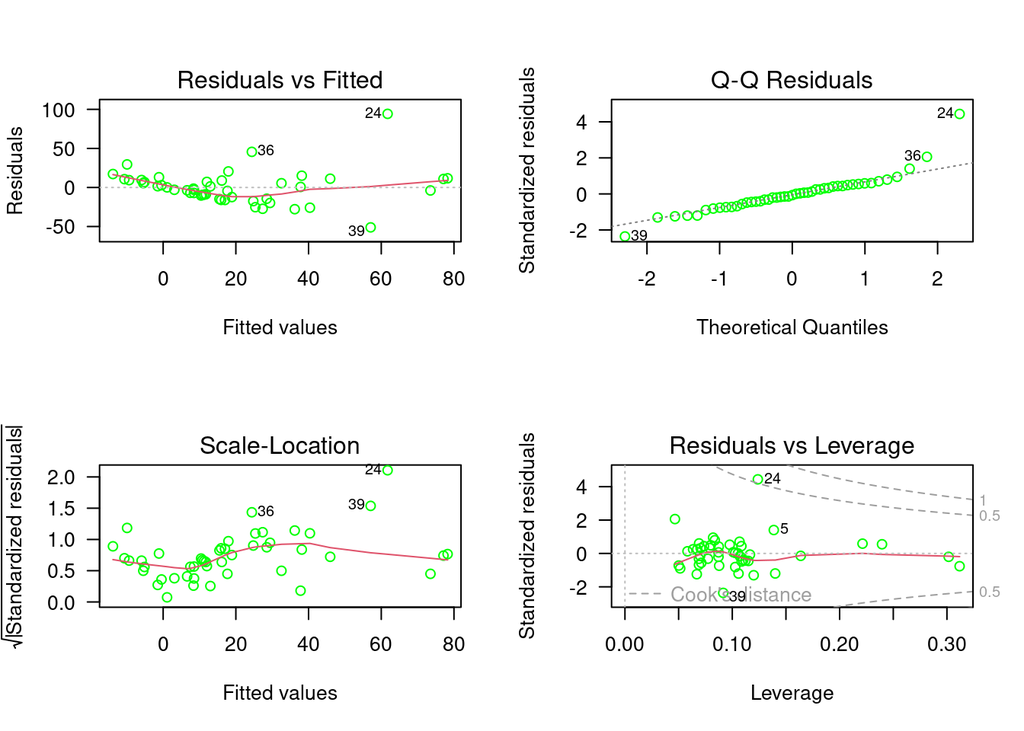

```r
par(mfrow=c(2, 2))
plot(modelolineal, las=1, col="green")
```

Se observan una serie de datos outliers que pueden estar influyendo mucho en el modelo. En el gráfico Q-Q se pueden ver colas

- El porcentaje de variación explicado por los predictores viene dado por R<sup>2</sup> =0,5267, 52%.
  - Este valor de R<sup>2</sup> es bajo.
- ¿Que observación tiene el residuo positivo más grande?
  - Para ver los parámetros que podemos visualizar del modelo se puede realizar

```r
        # Para ver la información que podemos obtener del objeto ( modelo ) modelolineal
names(modelolineal)
```

```
##  [1] "coefficients"  "residuals"     "effects"       "rank"
##  [5] "fitted.values" "assign"        "qr"            "df.residual"
##  [9] "contrasts"     "xlevels"       "call"          "terms"
## [13] "model"
```

De aquí visualizamos los datos de los valores residuales y obtenemos el máximo.

```r
modelolineal$residuals
```

```
##           1           2           3           4           5           6
##  10.6507430   9.3711318   5.4630298 -17.4957487  29.5194692  -2.9846919
##           7           8           9          10          11          12
##  -7.0242994 -12.3060734   6.8496267 -10.3329505   1.5934936  -3.0958161
##          13          14          15          16          17          18
##   0.1172839   9.5331344   2.8488167  17.2107726 -25.2627227 -27.7998544
##          19          20          21          22          23          24
##  13.1446553 -15.9510624 -16.0041386  -9.5801478 -27.2711657  94.2522174
##          25          26          27          28          29          30
##   0.6993361  -9.1670510 -25.8747696  -8.7455549  -6.8803097 -19.8090866
##          31          32          33          34          35          36
##  10.8793766  15.0599340  11.7462296  -3.5932770 -14.4016736  45.6051264
##          37          38          39          40          41          42
##  20.5472529  11.2429290 -51.0824078   8.8669438  -1.4513921  -3.8361619
##          43          44          45          46          47
##  -4.3831786 -14.8940753   5.4506347   1.4092321   7.1662399
```

```r
#Vemos el máximo con la función max()
max(modelolineal$residuals)
```

```
## [1] 94.25222
```

Que se corresponde con la entrada 24

- Muestra la media y la mediana de los residuos..

A partir de la información obtenida en el apartado anterior…

```r
cat("La media de los residuos del modelo es ",mean(modelolineal$residuals),"\n" )
```

```
## La media de los residuos del modelo es  2.479547e-16
```

```r
cat("La mediana de los residuos del modelo es ", median(modelolineal$residuals))
```

```
## La mediana de los residuos del modelo es  -1.451392
```

- Calcule la correlación de los residuos con los valores ajustados.

```r
#Obtenemos los residuos y los valores del modelo .
cor(modelolineal$residuals, modelolineal$fitted.values)
```

```
## [1] 3.804315e-17
```

- Correlación de los residuos con los ingresos

```r
cor(modelolineal$residuals,teengamb$income)
```

```
## [1] 3.738319e-17
```

- Predicciones del gasto en juego comparadas por sexo.

  Se pueden obtener a partir del resumen del modelo. Cruzando la columna estimado con sexo. Esto da -22.11833$
2. El dataset uswages se ha obtenido de una muestra del estudio de población …….

```r
data("uswages",package="faraway")
head(uswages)
```

```
##         wage educ exper race smsa ne mw so we pt
## 6085  771.60   18    18    0    1  1  0  0  0  0
## 23701 617.28   15    20    0    1  0  0  0  1  0
## 16208 957.83   16     9    0    1  0  0  1  0  0
## 2720  617.28   12    24    0    1  1  0  0  0  0
## 9723  902.18   14    12    0    1  0  1  0  0  0
## 22239 299.15   12    33    0    1  0  0  0  1  0
```

```r
str(uswages)
```

```
## 'data.frame':    2000 obs. of  10 variables:
##  $ wage : num  772 617 958 617 902 ...
##  $ educ : int  18 15 16 12 14 12 16 16 12 12 ...
##  $ exper: int  18 20 9 24 12 33 42 0 36 37 ...
##  $ race : int  0 0 0 0 0 0 0 0 0 0 ...
##  $ smsa : int  1 1 1 1 1 1 1 1 1 0 ...
##  $ ne   : int  1 0 0 1 0 0 0 0 0 0 ...
##  $ mw   : int  0 0 0 0 1 0 0 1 0 1 ...
##  $ so   : int  0 0 1 0 0 0 1 0 0 0 ...
##  $ we   : int  0 1 0 0 0 1 0 0 1 0 ...
##  $ pt   : int  0 0 0 0 0 0 1 1 1 0 ...
```

El nº de datos faltantes es

```r
apply(X = is.na(uswages), MARGIN = 2, FUN = sum)
```

```
##  wage  educ exper  race  smsa    ne    mw    so    we    pt
##     0     0     0     0     0     0     0     0     0     0
```

Realizaremos la conversión de los últimos 7 parámetros a factor.

```r
uswages$race<-factor(uswages$race)
levels(uswages$race)<-c("Negro","Blanco")
uswages$smsa<-factor(uswages$smsa)
levels(uswages$smsa)<-c("Area","NotArea")
uswages$ne<-factor(uswages$ne)
levels(uswages$ne)<-c("NE","NotNE")
uswages$mw<-factor(uswages$mw)
levels(uswages$mw)<-c("MW","NotMW")
uswages$we<-factor(uswages$we)
levels(uswages$we)<-c("WE","NotWE")
uswages$so<-factor(uswages$so)
levels(uswages$so)<-c("SO","NotSO")
uswages$pt<-factor(uswages$pt)
levels(uswages$pt)<-c("pt","Notpt")
```

Observemos los datos a partir de gráficas

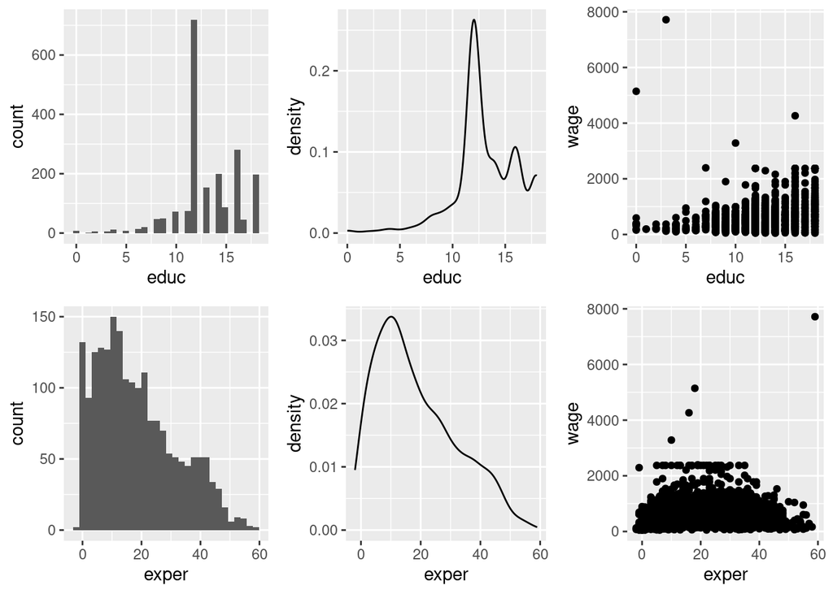

```r
g1<-ggplot(uswages,aes(x=educ))+geom_histogram(bins = 30)
g2<-ggplot(uswages,aes(x=educ))+geom_density()
g3<-ggplot(uswages,aes(x=educ,y=wage))+geom_point()
g4<-ggplot(uswages,aes(x=exper))+geom_histogram(bins=30)
g5<-ggplot(uswages,aes(x=exper))+geom_density()
g6<-ggplot(uswages,aes(x=exper,y=wage))+geom_point()
grid.arrange(g1,g2,g3,g4,g5,g6,ncol=3)
```

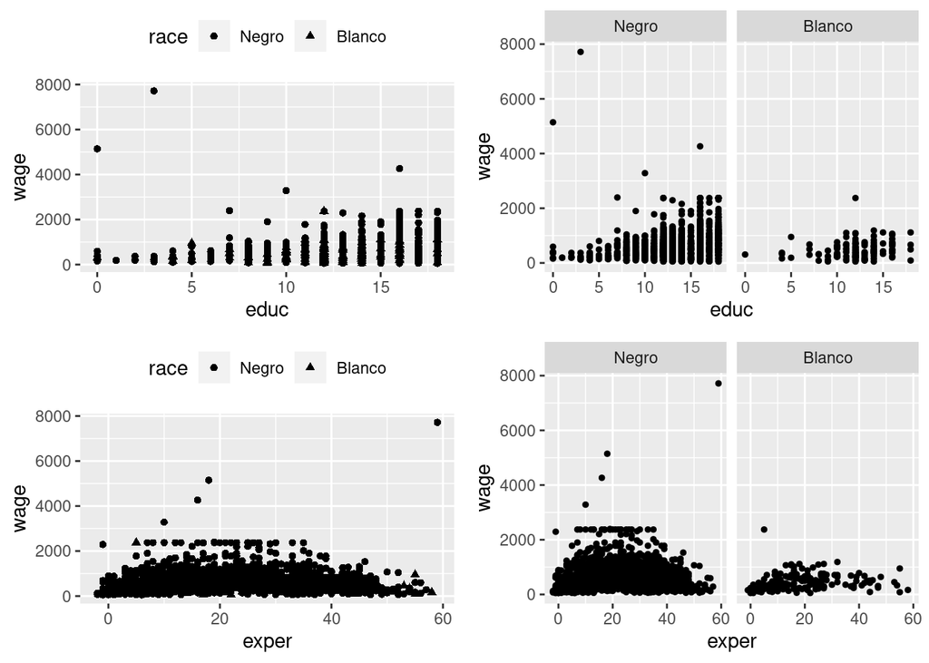

```r
g7<-ggplot(uswages,aes(x=educ,y=wage, shape=race))+geom_point(na.rm=TRUE)+theme(legend.position = "top",legend.direction ="horizontal")
g8<-ggplot(uswages,aes(x=educ,y=wage))+geom_point(na.rm=TRUE,size=1)+facet_grid(~ race)
g9<-ggplot(uswages,aes(x=exper,y=wage, shape=race))+geom_point(na.rm=TRUE)+theme(legend.position = "top",legend.direction ="horizontal")
g10<-ggplot(uswages,aes(x=exper,y=wage))+geom_point(na.rm=TRUE,size=1)+facet_grid(~ race)
grid.arrange(g7,g8,g9,g10,ncol=2)
```

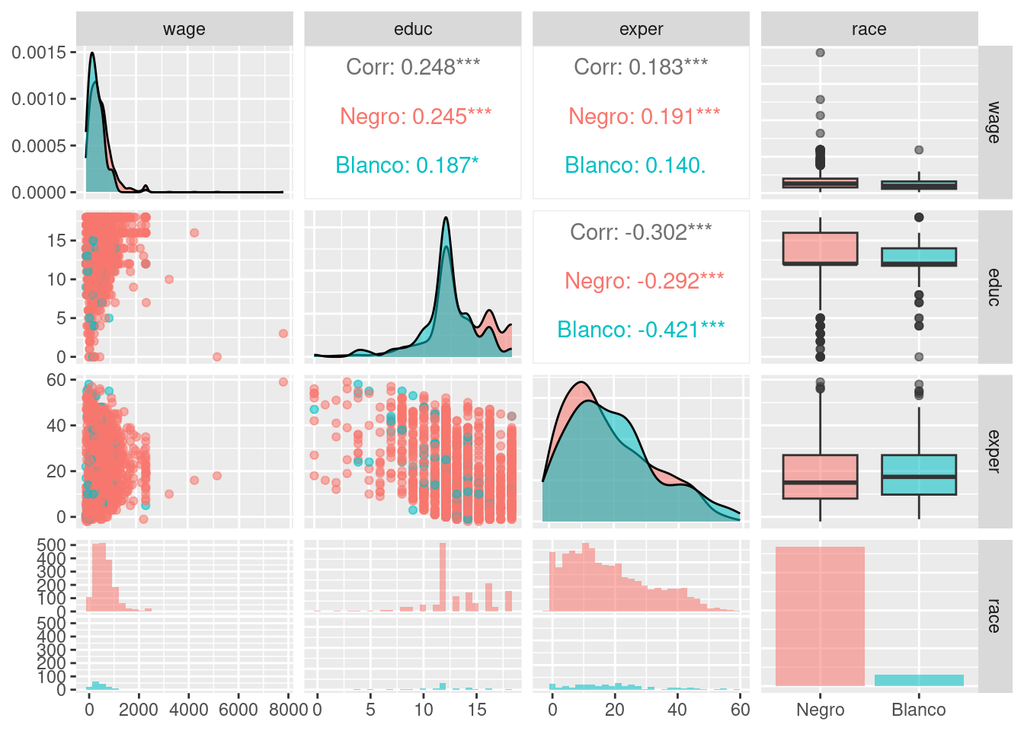

```r
library(GGally)
ggpairs(uswages[,1:4], aes(colour = race, alpha = 0.4))
```

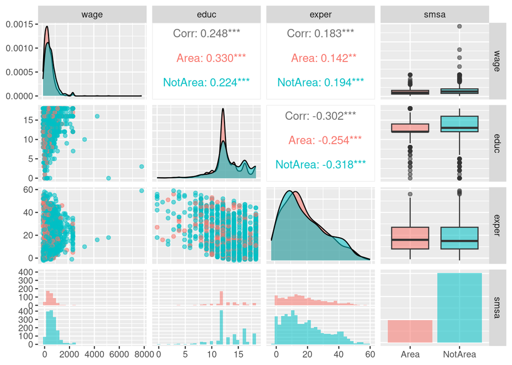

```r
ggpairs(uswages[,c(1,2,3,5)], aes(colour = smsa, alpha = 0.4))
```

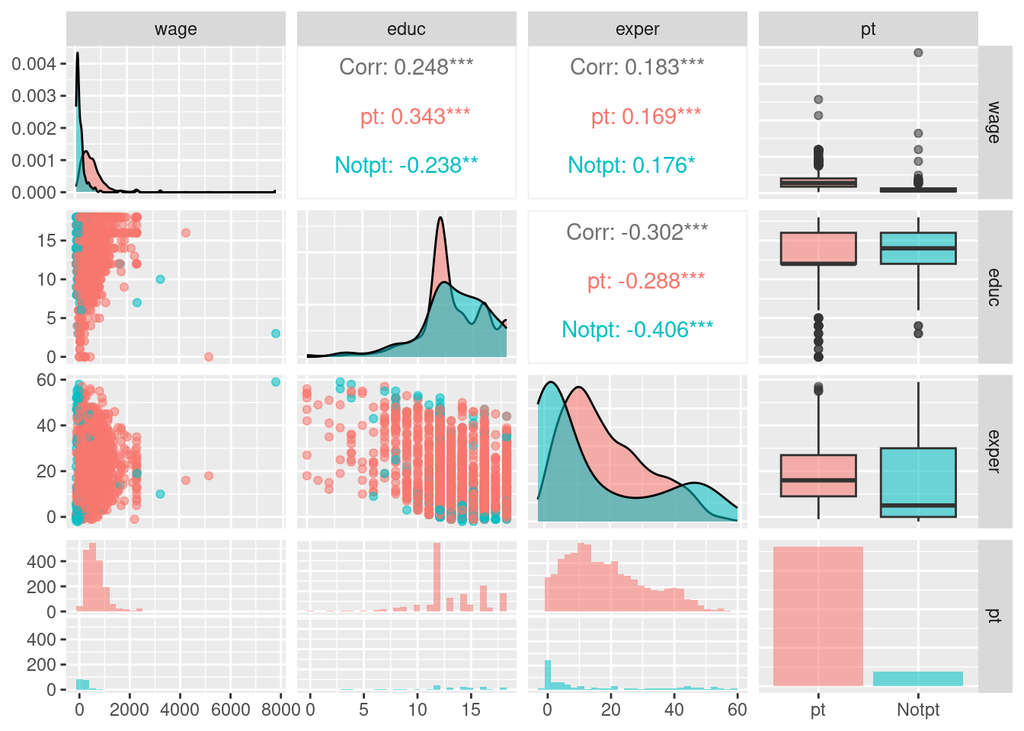

```r
ggpairs(uswages[,c(1,2,3,10)], aes(colour = pt, alpha = 0.4))
```

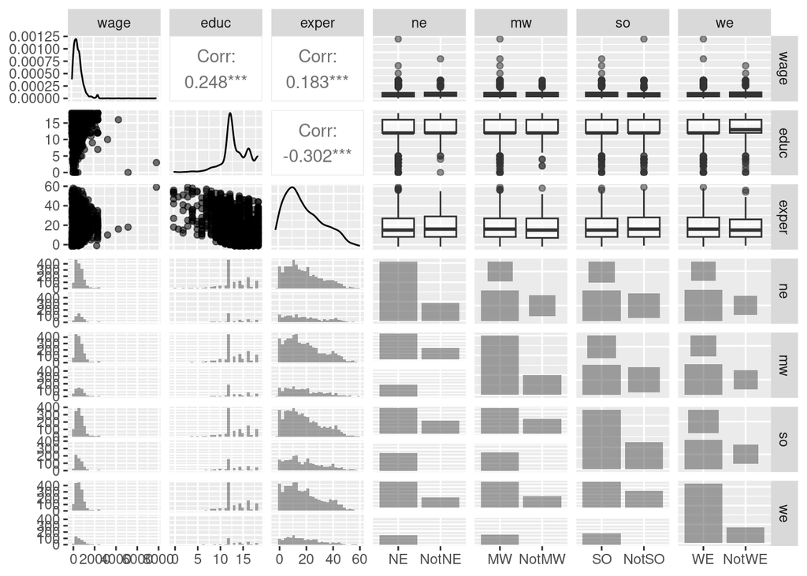

```r
ggpairs(uswages[,c(1,2,3,6,7,8,9)], aes(alpha = 0.4))
```

Se crea el modelo en base los predictores años de experiencia y educación

modelosalario

```r
modelosalario<-lm(wage~exper+educ,data=uswages)
summary(modelosalario)
```

```
##
## Call:
## lm(formula = wage ~ exper + educ, data = uswages)
##
## Residuals:
##     Min      1Q  Median      3Q     Max
## -1018.2  -237.9   -50.9   149.9  7228.6
##
## Coefficients:
##              Estimate Std. Error t value Pr(>|t|)
## (Intercept) -242.7994    50.6816  -4.791 1.78e-06 ***
## exper          9.7748     0.7506  13.023  < 2e-16 ***
## educ          51.1753     3.3419  15.313  < 2e-16 ***
## ---
## Signif. codes:  0 '***' 0.001 '**' 0.01 '*' 0.05 '.' 0.1 ' ' 1
##
## Residual standard error: 427.9 on 1997 degrees of freedom
## Multiple R-squared:  0.1351, Adjusted R-squared:  0.1343
## F-statistic:   156 on 2 and 1997 DF,  p-value: < 2.2e-16
```

El parámetro porcentaje de varianza explicada o o coeficiente de determinación R<sup>2</sup> es 0.135 , muy bajo.

Interpretación del coeficiente de regresión para años de educación

```r
modelosalario$coefficients
```

```
## (Intercept)       exper        educ
## -242.799412    9.774767   51.175268
```

```r
cat("maximo de años de educación",max(uswages$educ),"\n")
```

```
## maximo de años de educación 18
```

```r
cat("maximo de años de experiencia",max(uswages$exper))
```

```
## maximo de años de experiencia 59
```

y el coeficiente varía en cinco veces, los años de educación son mucho más importantes en el salario.

- El nuevo modelo con el logaritmo

  ```r
  modelosalariolog<-lm(log(wage)~exper+educ,data=uswages)
  summary(modelosalariolog)
  ```

  ```
  ##
  ## Call:
  ## lm(formula = log(wage) ~ exper + educ, data = uswages)
  ##
  ## Residuals:
  ##     Min      1Q  Median      3Q     Max
  ## -2.7533 -0.3495  0.1068  0.4381  3.5699
  ##
  ## Coefficients:
  ##             Estimate Std. Error t value Pr(>|t|)
  ## (Intercept) 4.650319   0.078354   59.35   <2e-16 ***
  ## exper       0.018079   0.001160   15.58   <2e-16 ***
  ## educ        0.090506   0.005167   17.52   <2e-16 ***
  ## ---
  ## Signif. codes:  0 '***' 0.001 '**' 0.01 '*' 0.05 '.' 0.1 ' ' 1
  ##
  ## Residual standard error: 0.6615 on 1997 degrees of freedom
  ## Multiple R-squared:  0.1749, Adjusted R-squared:  0.174
  ## F-statistic: 211.6 on 2 and 1997 DF,  p-value: < 2.2e-16
  ```

  ```r
  modelosalariolog$coefficients
  ```

  ```
  ## (Intercept)       exper        educ
  ##  4.65031905  0.01807855  0.09050628
  ```

3. Investigación sobre algunos datos para comparar los métodos de cálculo de coeficientes

```r
set.seed(1234)
x<-1:20
y<-x+rnorm(20)
#Utilizamos el método directo.
#Guardamos los valores de los predictores en un vector
x1<-cbind(1,x,x^2)
#Formula para encontrar el coeficiente de regresión a partir de las indicaciones de la página 19 del libro de Faraway.
B<-solve(t(x1) %*% x1) %*% t(x1)%*%y

#Creamos un polinomio de grado dos con la función lm
mdel2<-lm(y~x+I(x^2))
# A partir del modelo creado se obtienen los coeficientes
coef_B<-coef(mdel2)
```

Ahora comparamos los parámetros obtenidos

```r
print(B)
```

```
##         [,1]
##   0.03634227
## x 0.85952766
##   0.00827842
```

```r
print(coef_B)
```

```
## (Intercept)           x      I(x^2)
##  0.03634227  0.85952766  0.00827842
```

Como vemos los resultados en un polinomio de grado dos son prácticamente los mismos. Veamos un polinomio de grado 3

```r
x3<-cbind(1,x,x^2,x^3)
#Formula para encontrar el coeficiente de regresión a partir de las indicaciones de la página 19 del libro de Faraway.
B3<-solve(t(x3) %*% x3) %*% t(x3)%*%y

#Creamos un polinomio de grado dos con la función lm
mdel3<-lm(y~x+I(x^2)+I(x^3))

# A partir del modelo creado se obtienen los coeficientes
coef_B3<-coef(mdel3)
#Revisamos parámetros
print(B3)
```

```
##           [,1]
##   -0.847060132
## x  1.310290677
##   -0.044097217
##    0.001662719
```

```r
print(coef_B3)
```

```
##  (Intercept)            x       I(x^2)       I(x^3)
## -0.847060132  1.310290677 -0.044097217  0.001662719
```

No falla

```r
x4<-cbind(1,x,x^2,x^3,x^4)
#Formula para encontrar el coeficiente de regresión a partir de las indicaciones de la página 19 del libro de Faraway.
B4<-solve(t(x4) %*% x4) %*% t(x4)%*%y

#Creamos un polinomio de grado dos con la función lm
mdel4<-lm(y~x+I(x^2)+I(x^3)+I(x^4))

# A partir del modelo creado se obtienen los coeficientes
coef_B4<-coef(mdel4)
#Revisamos parámetros
print(B4)
```

```
##            [,1]
##   -5.932315e-01
## x  1.111726e+00
##   -3.916449e-03
##   -1.263500e-03
##    6.967188e-05
```

```r
print(coef_B4)
```

```
##   (Intercept)             x        I(x^2)        I(x^3)        I(x^4)
## -5.932315e-01  1.111726e+00 -3.916449e-03 -1.263500e-03  6.967188e-05
```

Con x^5

```r
x5<-cbind(1,x,x^2,x^3,x^4,x^5)
#Formula para encontrar el coeficiente de regresión a partir de las indicaciones de la página 19 del libro de Faraway.
B5<-solve(t(x5) %*% x5) %*% t(x5)%*%y
#Creamos un polinomio de grado dos con la función lm
mdel5<-lm(y~x+I(x^2)+I(x^3)+I(x^4)+I(x^5))
# A partir del modelo creado se obtienen los coeficientes
coef_B5<-coef(mdel5)
#Revisamos parámetros
print(B5)
```

```
##            [,1]
##   -3.5179454826
## x  4.2281673232
##   -0.9446223598
##    0.1135671649
##   -0.0059993985
##    0.0001156013
```

```r
print(coef_B5)
```

```
##   (Intercept)             x        I(x^2)        I(x^3)        I(x^4)
## -3.5179454681  4.2281673223 -0.9446223600  0.1135671649 -0.0059993985
##        I(x^5)
##  0.0001156013
```

Con grado 6

```r
"
x6<-cbind(1,x,x^2,x^3,x^4,x^5,x^6)
#Formula para encontrar el coeficiente de regresión a partir de las indicaciones de la página 19 del libro de Faraway.
B6<-solve(t(x6) %*% x6) %*% t(x6)%*%y
#Creamos un polinomio de grado dos con la función lm
mdel6<-lm(y~x+I(x^2)+I(x^3)+I(x^4)+I(x^5)+I(x^6))
# A partir del modelo creado se obtienen los coeficientes
coef_B6<-coef(mdel6)
#Revisamos parámetros
print(B6)
print(coef_B6)"
```

[output not shown]

Error in solve.default(t(x6) %*% x6) : sistema es computacionalmente singular: número de condición recíproco = 3.54243e-18

El error nos da por sistema singular, es decir la matriz no puede ser transpuesta

4. El dataset prostata viene de un estudio con 97 hombres con cancer de próstata que han recibido una prostatectomía radical…..

```r
data("prostate",package="faraway")
head(prostate)
```

```
##       lcavol lweight age      lbph svi      lcp gleason pgg45     lpsa
## 1 -0.5798185  2.7695  50 -1.386294   0 -1.38629       6     0 -0.43078
## 2 -0.9942523  3.3196  58 -1.386294   0 -1.38629       6     0 -0.16252
## 3 -0.5108256  2.6912  74 -1.386294   0 -1.38629       7    20 -0.16252
## 4 -1.2039728  3.2828  58 -1.386294   0 -1.38629       6     0 -0.16252
## 5  0.7514161  3.4324  62 -1.386294   0 -1.38629       6     0  0.37156
## 6 -1.0498221  3.2288  50 -1.386294   0 -1.38629       6     0  0.76547
```

```r
str(prostate)
```

```
## 'data.frame':    97 obs. of  9 variables:
##  $ lcavol : num  -0.58 -0.994 -0.511 -1.204 0.751 ...
##  $ lweight: num  2.77 3.32 2.69 3.28 3.43 ...
##  $ age    : int  50 58 74 58 62 50 64 58 47 63 ...
##  $ lbph   : num  -1.39 -1.39 -1.39 -1.39 -1.39 ...
##  $ svi    : int  0 0 0 0 0 0 0 0 0 0 ...
##  $ lcp    : num  -1.39 -1.39 -1.39 -1.39 -1.39 ...
##  $ gleason: int  6 6 7 6 6 6 6 6 6 6 ...
##  $ pgg45  : int  0 0 20 0 0 0 0 0 0 0 ...
##  $ lpsa   : num  -0.431 -0.163 -0.163 -0.163 0.372 ...
```

```r
# El valor svi es una variable dicotómica por lo que lo convertimos en un factor.

prostate$svi<-factor(prostate$svi)
levels(prostate$svi)<-c("No","Si")
```

Generamos el primer modelo

```r
md1_prostate<-lm(lpsa~lcavol,data=prostate)
summary(md1_prostate)
```

```
##
## Call:
## lm(formula = lpsa ~ lcavol, data = prostate)
##
## Residuals:
##      Min       1Q   Median       3Q      Max
## -1.67625 -0.41648  0.09859  0.50709  1.89673
##
## Coefficients:
##             Estimate Std. Error t value Pr(>|t|)
## (Intercept)  1.50730    0.12194   12.36   <2e-16 ***
## lcavol       0.71932    0.06819   10.55   <2e-16 ***
## ---
## Signif. codes:  0 '***' 0.001 '**' 0.01 '*' 0.05 '.' 0.1 ' ' 1
##
## Residual standard error: 0.7875 on 95 degrees of freedom
## Multiple R-squared:  0.5394, Adjusted R-squared:  0.5346
## F-statistic: 111.3 on 1 and 95 DF,  p-value: < 2.2e-16
```

```r
md2_prostate<-lm(lpsa~lcavol+lweight,data=prostate)
md3_prostate<-lm(lpsa~lcavol+lweight+svi,data=prostate)
md4_prostate<-lm(lpsa~lcavol+lweight+svi+lbph,data=prostate)
md5_prostate<-lm(lpsa~lcavol+lweight+svi+lbph+age,data=prostate)
md6_prostate<-lm(lpsa~lcavol+lweight+svi+lbph+age+lcp,data=prostate)
md7_prostate<-lm(lpsa~lcavol+lweight+svi+lbph+age+lcp+pgg45,data=prostate)
md8_prostate<-lm(lpsa~lcavol+lweight+svi+lbph+age+lcp+pgg45+gleason,data=prostate)
```

Obtengamos los ERS y los R<sup>2</sup>

```r
RSEVector<-c(summary(md1_prostate)$sigma,summary(md2_prostate)$sigma,summary(md3_prostate)$sigma,summary(md4_prostate)$sigma,summary(md5_prostate)$sigma,summary(md6_prostate)$sigma,summary(md7_prostate)$sigma,summary(md8_prostate)$sigma)
R2Vector<-c(summary(md1_prostate)$r.squared,summary(md2_prostate)$r.squared,summary(md3_prostate)$r.squared,summary(md4_prostate)$r.squared,summary(md5_prostate)$r.squared,summary(md6_prostate)$r.squared,summary(md7_prostate)$r.squared,summary(md8_prostate)$r.squared)
RSEVector
```

```
## [1] 0.7874994 0.7506469 0.7168094 0.7108232 0.7073054 0.7102135 0.7047533
## [8] 0.7084155
```

```r
R2Vector
```

```
## [1] 0.5394319 0.5859345 0.6264403 0.6366035 0.6441024 0.6451130 0.6544317
## [8] 0.6547541
```

Graficamos

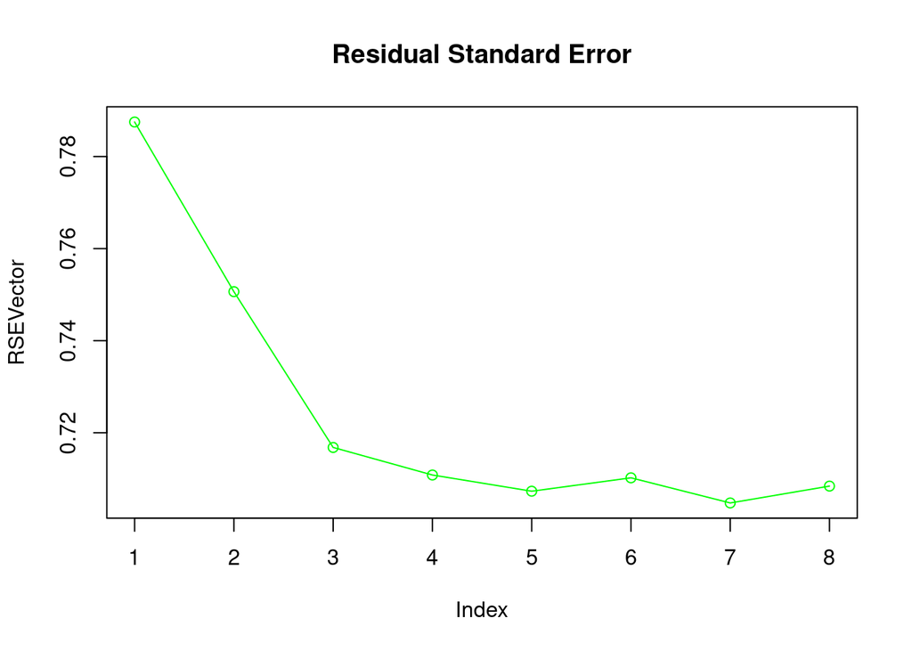

```r
plot(RSEVector,type = "o",col="green",main="Residual Standard Error")
```

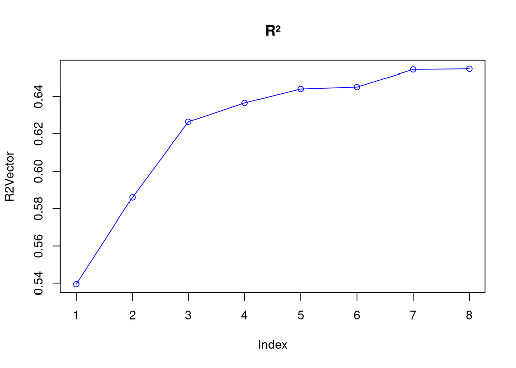

```r
plot(R2Vector, type="o", col="blue",main="R²")
```

Como se ve al aumentar el número de parámetros se aumenta la fiabilidad del modelo.

5. Comparar las regresiones que se obtienen al intercambiar lpsa y lcavol como variables dependientes.

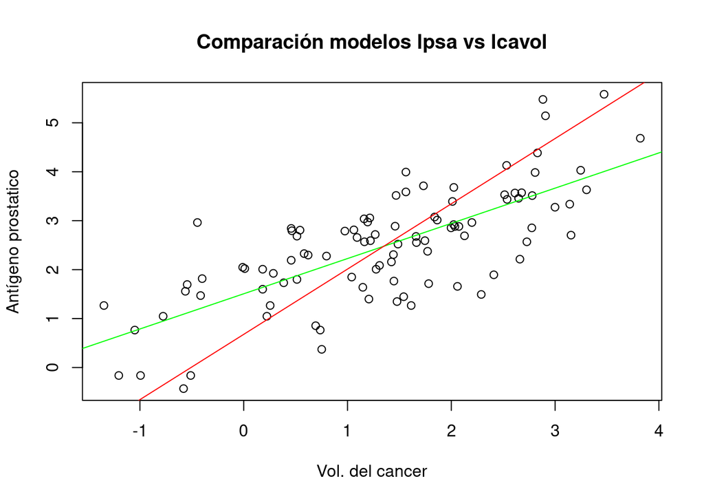

```r
lpsa_Dep_model<-lm(lpsa~lcavol, prostate)
lcavol_Dep_model<-lm(lcavol~lpsa,prostate)
# Graficamos las regresiones
plot(x=prostate$lcavol,y=prostate$lpsa, type='p', main="Comparación modelos lpsa vs lcavol", xlab="Vol. del cancer", ylab="Antígeno prostatico")
abline(lpsa_Dep_model, col="green")

abline(a=-coef(lcavol_Dep_model)[1]/coef(lcavol_Dep_model)[2],b=1/coef(lcavol_Dep_model)[2] ,col ="red")
```

Para verificar el punto de corte, se resuelve el sistema de ecuaciones

```r
Ter_ind<-c(coef(lcavol_Dep_model)[1],c(coef(lpsa_Dep_model)[1]))
M_Coef<-matrix(c(1,-coef(lpsa_Dep_model)[2],-coef(lcavol_Dep_model)[2],1),ncol=2,nrow=2,byrow=F)
solve(M_Coef,Ter_ind)
```

```
## [1] 1.350010 2.478387
```

6. Treinta muestras de queso cheddar fueron analizadas….

Siguiendo los pasos de la página 19 del libro de Faraway

```r
data("cheddar",package="faraway")
head(cheddar)
```

```
##   taste Acetic   H2S Lactic
## 1  12.3  4.543 3.135   0.86
## 2  20.9  5.159 5.043   1.53
## 3  39.0  5.366 5.438   1.57
## 4  47.9  5.759 7.496   1.81
## 5   5.6  4.663 3.807   0.99
## 6  25.9  5.697 7.601   1.09
```

```r
str(cheddar)
```

```
## 'data.frame':    30 obs. of  4 variables:
##  $ taste : num  12.3 20.9 39 47.9 5.6 25.9 37.3 21.9 18.1 21 ...
##  $ Acetic: num  4.54 5.16 5.37 5.76 4.66 ...
##  $ H2S   : num  3.13 5.04 5.44 7.5 3.81 ...
##  $ Lactic: num  0.86 1.53 1.57 1.81 0.99 1.09 1.29 1.78 1.29 1.58 ...
```

Realizamos el modelo lineal

```r
model_ches<-lm(taste~Acetic+H2S+Lactic,cheddar)
summary(model_ches)
```

```
##
## Call:
## lm(formula = taste ~ Acetic + H2S + Lactic, data = cheddar)
##
## Residuals:
##     Min      1Q  Median      3Q     Max
## -17.390  -6.612  -1.009   4.908  25.449
##
## Coefficients:
##             Estimate Std. Error t value Pr(>|t|)
## (Intercept) -28.8768    19.7354  -1.463  0.15540
## Acetic        0.3277     4.4598   0.073  0.94198
## H2S           3.9118     1.2484   3.133  0.00425 **
## Lactic       19.6705     8.6291   2.280  0.03108 *
## ---
## Signif. codes:  0 '***' 0.001 '**' 0.01 '*' 0.05 '.' 0.1 ' ' 1
##
## Residual standard error: 10.13 on 26 degrees of freedom
## Multiple R-squared:  0.6518, Adjusted R-squared:  0.6116
## F-statistic: 16.22 on 3 and 26 DF,  p-value: 3.81e-06
```

Los coeficientes de la regresión son

```r
print(model_ches$coefficients)
```

```
## (Intercept)      Acetic         H2S      Lactic
## -28.8767696   0.3277413   3.9118411  19.6705434
```

Obtenemos la matriz

```r
Rcuadrado<-(cor(cheddar$taste,model_ches$fitted.values))**2
print(Rcuadrado)
```

```
## [1] 0.6517747
```

Se correspondee con R².

Creemos un modelos sin intercepto.

```r
model_ches<-lm(taste~-1+Acetic+H2S+Lactic,cheddar)
summary(model_ches)
```

```
##
## Call:
## lm(formula = taste ~ -1 + Acetic + H2S + Lactic, data = cheddar)
##
## Residuals:
##      Min       1Q   Median       3Q      Max
## -15.4521  -6.5262  -0.6388   4.6811  28.4744
##
## Coefficients:
##        Estimate Std. Error t value Pr(>|t|)
## Acetic   -5.454      2.111  -2.583  0.01553 *
## H2S       4.576      1.187   3.854  0.00065 ***
## Lactic   19.127      8.801   2.173  0.03871 *
## ---
## Signif. codes:  0 '***' 0.001 '**' 0.01 '*' 0.05 '.' 0.1 ' ' 1
##
## Residual standard error: 10.34 on 27 degrees of freedom
## Multiple R-squared:  0.8877, Adjusted R-squared:  0.8752
## F-statistic: 71.15 on 3 and 27 DF,  p-value: 6.099e-13
```

En este caso R<sup>2</sup> es de 0.8877

Calculo de los coeficientes de regresión por el método QR.

```r
x<-model.matrix(~Acetic+H2S+Lactic,cheddar)
y<-cheddar$taste
qrx<-qr(x)
qr.Q(qrx)
```

```
##             [,1]        [,2]        [,3]        [,4]
##  [1,] -0.1825742 -0.31065328 -0.06752051  0.20213863
##  [2,] -0.1825742 -0.11028078 -0.01312827 -0.17396483
##  [3,] -0.1825742 -0.04294781 -0.02218665 -0.15579890
##  [4,] -0.1825742  0.08488725  0.10587684 -0.19116749
##  [5,] -0.1825742 -0.27161968 -0.02357504  0.14535806
##  [6,] -0.1825742  0.06471989  0.13338844  0.41839286
##  [7,] -0.1825742  0.12814949  0.20846447  0.33746987
##  [8,] -0.1825742  0.18865158  0.07651248 -0.09252507
##  [9,] -0.1825742 -0.19517887 -0.07888166 -0.07253067
## [10,] -0.1825742 -0.08328253 -0.13085098 -0.25049511
## [11,] -0.1825742  0.07870693 -0.03962703 -0.15563097
## [12,] -0.1825742  0.30835464 -0.02401390 -0.14248642
## [13,] -0.1825742 -0.33212177 -0.06608242  0.01443133
## [14,] -0.1825742 -0.08523421 -0.04403067  0.02812835
```

[output cut: 16 more lines]

```r
(f<-t(qr.Q(qrx))%*%y)
```

```
##            [,1]
## [1,] -134.37460
## [2,]   48.10552
## [3,]   46.33591
## [4,]  -23.09366
```

```r
backsolve(qr.R(qrx),f)
```

```
##             [,1]
## [1,] -28.8767696
## [2,]   0.3277413
## [3,]   3.9118411
## [4,]  19.6705434
```

7. Un experimento fue desarrollado para determinar el efecto de cuatro factores en la resistividad de una oblea de semiconductor….

```r
data("wafer",package="faraway")
head(wafer)
```

```
##   x1 x2 x3 x4 resist
## 1  -  -  -  -  193.4
## 2  +  -  -  -  247.6
## 3  -  +  -  -  168.2
## 4  +  +  -  -  205.0
## 5  -  -  +  -  303.4
## 6  +  -  +  -  339.9
```

```r
str(wafer)
```

```
## 'data.frame':    16 obs. of  5 variables:
##  $ x1    : Factor w/ 2 levels "-","+": 1 2 1 2 1 2 1 2 1 2 ...
##  $ x2    : Factor w/ 2 levels "-","+": 1 1 2 2 1 1 2 2 1 1 ...
##  $ x3    : Factor w/ 2 levels "-","+": 1 1 1 1 2 2 2 2 1 1 ...
##  $ x4    : Factor w/ 2 levels "-","+": 1 1 1 1 1 1 1 1 2 2 ...
##  $ resist: num  193 248 168 205 303 ...
```

```r
model_wafer<-lm(resist~x1+x2+x3+x4,wafer)
summary(model_wafer)
```

```
##
## Call:
## lm(formula = resist ~ x1 + x2 + x3 + x4, data = wafer)
##
## Residuals:
##     Min      1Q  Median      3Q     Max
## -43.381 -17.119   4.825  16.644  33.769
##
## Coefficients:
##             Estimate Std. Error t value Pr(>|t|)
## (Intercept)   236.78      14.77  16.032 5.65e-09 ***
## x1+            25.76      13.21   1.950 0.077085 .
## x2+           -69.89      13.21  -5.291 0.000256 ***
## x3+            43.59      13.21   3.300 0.007083 **
## x4+           -14.49      13.21  -1.097 0.296193
## ---
## Signif. codes:  0 '***' 0.001 '**' 0.01 '*' 0.05 '.' 0.1 ' ' 1
##
## Residual standard error: 26.42 on 11 degrees of freedom
## Multiple R-squared:  0.7996, Adjusted R-squared:  0.7267
## F-statistic: 10.97 on 4 and 11 DF,  p-value: 0.0007815
```

```r
xwafer<-model.matrix(~x1+x2+x3+x4,wafer)
```

Los parámetros se han determinado a partir de signos + o -.

```r
cor(xwafer)
```

```
##             (Intercept) x1+ x2+ x3+ x4+
## (Intercept)           1  NA  NA  NA  NA
## x1+                  NA   1   0   0   0
## x2+                  NA   0   1   0   0
## x3+                  NA   0   0   1   0
## x4+                  NA   0   0   0   1
```

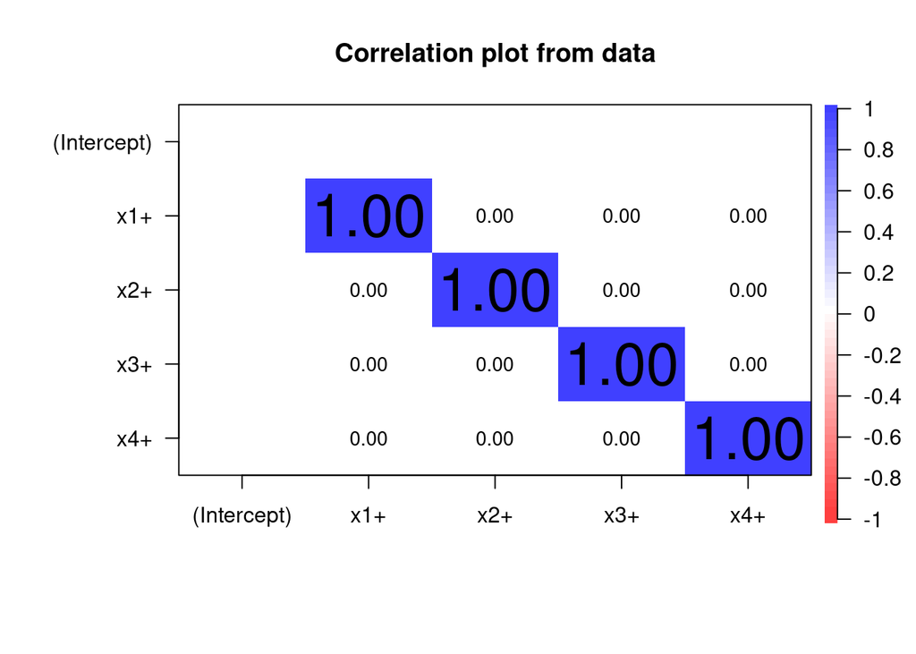

```r
cor.plot(xwafer)
```

Indica que los parámetros son independientes.

Falta opción 3

Redefinir el problema sin x4

```r
model_wafer_sinx4<-lm(resist~x1+x2+x3,wafer)
summary(model_wafer_sinx4)
```

```
##
## Call:
## lm(formula = resist ~ x1 + x2 + x3, data = wafer)
##
## Residuals:
##     Min      1Q  Median      3Q     Max
## -36.138 -20.550   3.575  18.463  41.012
##
## Coefficients:
##             Estimate Std. Error t value Pr(>|t|)
## (Intercept)   229.54      13.32  17.231 7.88e-10 ***
## x1+            25.76      13.32   1.934 0.077047 .
## x2+           -69.89      13.32  -5.246 0.000206 ***
## x3+            43.59      13.32   3.272 0.006677 **
## ---
## Signif. codes:  0 '***' 0.001 '**' 0.01 '*' 0.05 '.' 0.1 ' ' 1
##
## Residual standard error: 26.64 on 12 degrees of freedom
## Multiple R-squared:  0.7777, Adjusted R-squared:  0.7221
## F-statistic: 13.99 on 3 and 12 DF,  p-value: 0.0003187
```

Vemos que si bien al desaparecer la x4 pasa de un valor ajustado de R<sup>2</sup> =0.7267 a Adjust R<sup>2</sup> =0.7221 por lo que podemos deducir que la importancia de este parámetro en más bien menor.

8. Un experimento fue diseñado para examinar factores que pueden afectar a la altura de las ballestas en la suspensión de los camiones.

```r
data("truck",package="faraway")
head(truck)
```

```
##   B C D E O height
## 1 - - - - -   7.78
## 2 + - - + -   8.15
## 3 - + - + -   7.50
## 4 + + - - -   7.59
## 5 - - + + -   7.94
## 6 + - + - -   7.69
```

```r
str(truck)
```

```
## 'data.frame':    48 obs. of  6 variables:
##  $ B     : Factor w/ 2 levels "+","-": 2 1 2 1 2 1 2 1 2 1 ...
##  $ C     : Factor w/ 2 levels "+","-": 2 2 1 1 2 2 1 1 2 2 ...
##  $ D     : Factor w/ 2 levels "+","-": 2 2 2 2 1 1 1 1 2 2 ...
##  $ E     : Factor w/ 2 levels "+","-": 2 1 1 2 1 2 2 1 2 1 ...
##  $ O     : Factor w/ 2 levels "+","-": 2 2 2 2 2 2 2 2 1 1 ...
##  $ height: num  7.78 8.15 7.5 7.59 7.94 7.69 7.56 7.56 7.5 7.88 ...
```

Cambiamos los factores a valores -1, 1

```r
truck$B<-sapply(truck$B, function(x) ifelse(x=="-",-1,1))
truck$C<-sapply(truck$C, function(x) ifelse(x=="-",-1,1))
truck$D<-sapply(truck$D, function(x) ifelse(x=="-",-1,1))
truck$E<-sapply(truck$E, function(x) ifelse(x=="-",-1,1))
truck$O<-sapply(truck$O, function(x) ifelse(x=="-",-1,1))
head(truck)
```

```
##    B  C  D  E  O height
## 1 -1 -1 -1 -1 -1   7.78
## 2  1 -1 -1  1 -1   8.15
## 3 -1  1 -1  1 -1   7.50
## 4  1  1 -1 -1 -1   7.59
## 5 -1 -1  1  1 -1   7.94
## 6  1 -1  1 -1 -1   7.69
```

```r
str(truck)
```

```
## 'data.frame':    48 obs. of  6 variables:
##  $ B     : num  -1 1 -1 1 -1 1 -1 1 -1 1 ...
##  $ C     : num  -1 -1 1 1 -1 -1 1 1 -1 -1 ...
##  $ D     : num  -1 -1 -1 -1 1 1 1 1 -1 -1 ...
##  $ E     : num  -1 1 1 -1 1 -1 -1 1 -1 1 ...
##  $ O     : num  -1 -1 -1 -1 -1 -1 -1 -1 1 1 ...
##  $ height: num  7.78 8.15 7.5 7.59 7.94 7.69 7.56 7.56 7.5 7.88 ...
```

- Haz una regresión lineal con los cinco factores

```r
model_four_truck<-lm(height~B+C+D+E+O,truck)
summary(model_four_truck)
```

```
##
## Call:
## lm(formula = height ~ B + C + D + E + O, data = truck)
##
## Residuals:
##      Min       1Q   Median       3Q      Max
## -0.33125 -0.09427  0.01625  0.11917  0.25875
##
## Coefficients:
##             Estimate Std. Error t value Pr(>|t|)
## (Intercept)  7.63604    0.02291 333.316  < 2e-16 ***
## B            0.11062    0.02291   4.829 1.85e-05 ***
## C           -0.08813    0.02291  -3.847   0.0004 ***
## D           -0.01438    0.02291  -0.627   0.5337
## E            0.05187    0.02291   2.264   0.0288 *
## O           -0.12979    0.02291  -5.665 1.20e-06 ***
## ---
## Signif. codes:  0 '***' 0.001 '**' 0.01 '*' 0.05 '.' 0.1 ' ' 1
##
## Residual standard error: 0.1587 on 42 degrees of freedom
## Multiple R-squared:  0.6433, Adjusted R-squared:  0.6008
## F-statistic: 15.15 on 5 and 42 DF,  p-value: 1.681e-08
```

```r
model.matrix(~B+C+D+E+O,truck)
```

```
##    (Intercept)  B  C  D  E  O
## 1            1 -1 -1 -1 -1 -1
## 2            1  1 -1 -1  1 -1
## 3            1 -1  1 -1  1 -1
## 4            1  1  1 -1 -1 -1
## 5            1 -1 -1  1  1 -1
## 6            1  1 -1  1 -1 -1
## 7            1 -1  1  1 -1 -1
## 8            1  1  1  1  1 -1
## 9            1 -1 -1 -1 -1  1
## 10           1  1 -1 -1  1  1
## 11           1 -1  1 -1  1  1
## 12           1  1  1 -1 -1  1
## 13           1 -1 -1  1  1  1
## 14           1  1 -1  1 -1  1
```

[output cut: 36 more lines]

```r
cat("Los coeficientes son:\n")
```

```
## Los coeficientes son:
```

```r
model_four_truck$coefficients
```

```
## (Intercept)           B           C           D           E           O
##   7.6360417   0.1106250  -0.0881250  -0.0143750   0.0518750  -0.1297917
```

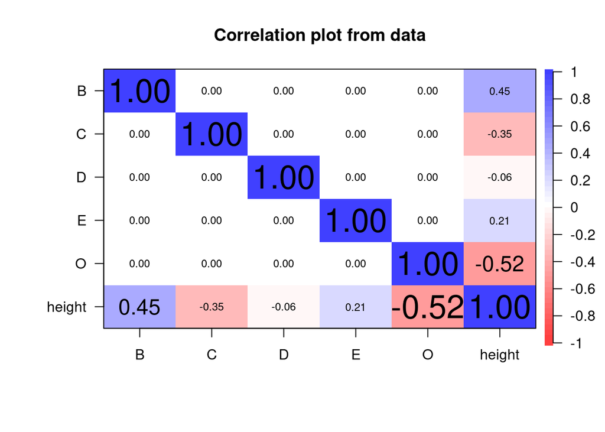

```r
cor.plot(truck)
```

- Compara la regresión lineal con otra con solo los cuatro primeros factores.

```r
model_four_truck<-lm(height~B+C+D+E,truck)
summary(model_four_truck)
```

```
##
## Call:
## lm(formula = height ~ B + C + D + E, data = truck)
##
## Residuals:
##      Min       1Q   Median       3Q      Max
## -0.46104 -0.12479 -0.00479  0.14396  0.34896
##
## Coefficients:
##             Estimate Std. Error t value Pr(>|t|)
## (Intercept)  7.63604    0.03007 253.915  < 2e-16 ***
## B            0.11062    0.03007   3.679 0.000648 ***
## C           -0.08813    0.03007  -2.930 0.005402 **
## D           -0.01438    0.03007  -0.478 0.635071
## E            0.05187    0.03007   1.725 0.091717 .
## ---
## Signif. codes:  0 '***' 0.001 '**' 0.01 '*' 0.05 '.' 0.1 ' ' 1
##
## Residual standard error: 0.2084 on 43 degrees of freedom
## Multiple R-squared:  0.3706, Adjusted R-squared:  0.3121
## F-statistic: 6.331 on 4 and 43 DF,  p-value: 0.0004258
```

```r
cat("Los coeficientes son:\n")
```

```
## Los coeficientes son:
```

```r
model_four_truck$coefficients
```

```
## (Intercept)           B           C           D           E
##    7.636042    0.110625   -0.088125   -0.014375    0.051875
```

```r
truck$A<-truck$B+truck$E+truck$D+truck$E
model_six_truck<-lm(height~A+B+C+D+E+O, truck)
summary(model_six_truck)
```

```
##
## Call:
## lm(formula = height ~ A + B + C + D + E + O, data = truck)
##
## Residuals:
##      Min       1Q   Median       3Q      Max
## -0.33125 -0.09427  0.01625  0.11917  0.25875
##
## Coefficients: (1 not defined because of singularities)
##             Estimate Std. Error t value Pr(>|t|)
## (Intercept)  7.63604    0.02291 333.316  < 2e-16 ***
## A            0.02594    0.01145   2.264  0.02878 *
## B            0.08469    0.02561   3.306  0.00194 **
## C           -0.08813    0.02291  -3.847  0.00040 ***
## D           -0.04031    0.02561  -1.574  0.12302
## E                 NA         NA      NA       NA
## O           -0.12979    0.02291  -5.665  1.2e-06 ***
## ---
## Signif. codes:  0 '***' 0.001 '**' 0.01 '*' 0.05 '.' 0.1 ' ' 1
##
## Residual standard error: 0.1587 on 42 degrees of freedom
## Multiple R-squared:  0.6433, Adjusted R-squared:  0.6008
## F-statistic: 15.15 on 5 and 42 DF,  p-value: 1.681e-08
```

```r
model_six_truck$coefficients
```

```
## (Intercept)           A           B           C           D           E
##   7.6360417   0.0259375   0.0846875  -0.0881250  -0.0403125          NA
##           O
##  -0.1297917
```

Existe multicolinealidad de las variables y el paquete elimina automáticamente del modelo las variables que estima son menos informativas.

- Extraer la matriz X del modelo anterior

```r
x_six<-model.matrix(~A+B+C+D+E+O,truck)
y_six<-truck$height
"
xtxi_six<-solve(t(x_six) %*% x_six)
#Obtenemos los coeficientes
xtxi_six %*% t(x_six) %*% y"
```

```
## [1] "\nxtxi_six<-solve(t(x_six) %*% x_six)\n#Obtenemos los coeficientes\nxtxi_six %*% t(x_six) %*% y"
```

Me dice que la matriz no es invertible, seguramente por la multicolinealidad.

- Use el método QR de descomposición e intente calcular B.

```r
"
#Calculamos la matriz Q
qrx<-qr(x_six)
#Calculamos f
#(f<-t(qr.Q(qrx)%*%y_six))

#Nuevo metodo
QR = qr(x_six)

Q = qr.Q(QR,complete = TRUE)
Ra = qr.R(QR,complete = TRUE)

Qf = qr.Q(QR,complete = FALSE)
R  = qr.R(QR,complete = FALSE)
dim(x_six)
p=ncol(x_six)
n=nrow(x_six)-1

f = matrix((t(Q)%*%y_six)[1:p,1],p,1)
r = matrix((t(Q)%*%y_six)[(p+1):n,1],n-p,1)

# --------------------------------------------
B_hat = solve(R)%*%f
B_hat
SCR = t(r)%*%r

SCT = t(y_six)%*%y_six- n*(mean(Y)^2)

B1_qr    = B_hat[1,1]
B2_qr    = B_hat[2,1]
B3_qr    = B_hat[3,1]
B4_qr    = B_hat[4,1]
s_qr     = sqrt(SCR/(n-p))
R2_qr    = 1 -  SCR/SCT
"
```

[output not shown]

Sigue dando que el sistema a resolver es singular.

Estime los coeficientes por qr.coef

```r
qr.coef(qr(x_six),y_six)
```

```
## (Intercept)           A           B           C           D           E
##   7.6360417   0.0259375   0.0846875  -0.0881250  -0.0403125          NA
##           O
##  -0.1297917
```

Obtenemos ahora los mismos coeficientes que con lm

## Ejercicios del libro de Carmona

1. Una variable Y toma los valores …..
- Según Carmona , pag 18, “un modelo es lineal si lo es para los parámetros” por lo que el último modelo, c , no es lineal.
- En este caso solo veo un vector de diseño c(1,2,3).
  1. 1 1 3
  2. 1 1 e<sup>2</sup>

  c)No es lineal.
2. Cuatro objetos cuyos pesos exactos son…..

   ```r
   ca2=data.frame(y=c(9.2,8.3,5.4,-1.6,8.7,3.5),b1=c(1,1,1,1,1,1),b2=c(1,-1,0,0,0,1),b3=c(1,1,0,0,1,-1),b4=c(1,1,1,-1,1,1))
   ca2
   ```

   ```
   ##      y b1 b2 b3 b4
   ## 1  9.2  1  1  1  1
   ## 2  8.3  1 -1  1  1
   ## 3  5.4  1  0  0  1
   ## 4 -1.6  1  0  0 -1
   ## 5  8.7  1  0  1  1
   ## 6  3.5  1  1 -1  1
   ```

   ```r
   md_pesas<-lm(y~b1+b2+b3+b4,ca2)
   summary(md_pesas)
   ```

   ```
   ##
   ## Call:
   ## lm(formula = y ~ b1 + b2 + b3 + b4, data = ca2)
   ##
   ## Residuals:
   ##          1          2          3          4          5          6
   ## -1.143e-02  1.571e-01 -3.371e-01  1.344e-17  2.286e-02  1.686e-01
   ##
   ## Coefficients: (1 not defined because of singularities)
   ##             Estimate Std. Error t value Pr(>|t|)
   ## (Intercept)   2.0686     0.1658  12.473  0.00637 **
   ## b1                NA         NA      NA       NA
   ## b2            0.5343     0.1956   2.731  0.11199
   ## b3            2.9400     0.1830  16.066  0.00385 **
   ## b4            3.6686     0.1658  22.120  0.00204 **
   ## ---
   ## Signif. codes:  0 '***' 0.001 '**' 0.01 '*' 0.05 '.' 0.1 ' ' 1
   ##
   ## Residual standard error: 0.2893 on 2 degrees of freedom
   ## Multiple R-squared:  0.9981, Adjusted R-squared:  0.9951
   ## F-statistic: 342.4 on 3 and 2 DF,  p-value: 0.002914
   ```

   Nos encontramos con que el parámetro B1 es una combinación lineal de otros vectores por lo que da lugar a singularidades. La función de R lm() lo obvia. La varianza del error es el error residual estandar 0.2893
3. En un modelo lineal la matriz de diseño es …. hayar la expresión general de las funciones paramétricas estimables.

   ```r
   C3<-data.frame(c(1,1,1,1,1),c(1,0,1,0,0),c(1,1,1,0,0),c(1,0,1,1,1))
   C3_M<-data.matrix(C3)
   qr(C3_M)$rank
   ```

   ```
   ## [1] 3
   ```

   Por lo que cogemos las ecuaciones y conformamos un sistema del que el resultado es

   a+b-c-d=0
4. Consideremos el modelo lineal….
- ¿Es la función 𝛙=B1+B2+B3 estimable?

Una función es estimable si es combinación lineal de las ecuaciones que conforman el modelo. En este caso no es una combinación lineal de la matriz reducida del modelo lineal. Se a de tener en cuenta que la primera y la última linea de la matriz de diseño son la misma.

- Siguiendo con el mismo razonamiento cualquier combinación lineal de la matriz reducida

```r
a<-data.frame(c(1,1),c(1,0),c(0,1))
a
```

```
##   c.1..1. c.1..0. c.0..1.
## 1       1       1       0
## 2       1       0       1
```

Una combinación lineal de las dos filas daría

$$(a_{11}+a_{21})*\alpha_{1}+(a_{12}+a_{22})*\alpha_{2}+(a_{13}+a_{23})*\alpha_{3}$$

Lo que correspondería a la ecuación propuesta.

- La matriz es

```r
C_A<-data.frame(c(1,1,1,1,1,1),c(1,1,0,0,0,0),c(0,0,1,1,0,0),c(0,0,0,0,1,1),c(1,0,1,0,1,0),c(0,1,0,1,0,1))
C_AM<-data.matrix(C_A)
C_AM
```

```
##      c.1..1..1..1..1..1. c.1..1..0..0..0..0. c.0..0..1..1..0..0.
## [1,]                   1                   1                   0
## [2,]                   1                   1                   0
## [3,]                   1                   0                   1
## [4,]                   1                   0                   1
## [5,]                   1                   0                   0
## [6,]                   1                   0                   0
##      c.0..0..0..0..1..1. c.1..0..1..0..1..0. c.0..1..0..1..0..1.
## [1,]                   0                   1                   0
## [2,]                   0                   0                   1
## [3,]                   0                   1                   0
## [4,]                   0                   0                   1
## [5,]                   1                   1                   0
## [6,]                   1                   0                   1
```

```r
cat("El rango de la matriz es ")
```

```
## El rango de la matriz es
```

```r
qr(C_A)$rank
```

```
## [1] 4
```

El rango de la matriz es 4.

```r
C_Aa<-rbind(C_A,c(0,1,1,0,0,0))
qr(C_Aa)$rank
```

```
## [1] 5
```

La fila añadida no es la combinación lineal de las filas preexistentes y el rango sube 1. Por lo tanto no es estimable

  ```r
  C_Ab<-rbind(C_A,c(0,0,0,1,-1,0))
  qr(C_Ab)$rank
  ```

  ```
  ## [1] 5
  ```

Estamos en el mismo caso.

- Es el mismo caso.
- ¿Es 6u+2a1+2a2+2a3+3b1+3b2 estimable?

  ```r
  C_Ac<-rbind(C_A,c(6,2,2,2,3,3))
  qr(C_Ac)$rank
  ```

  ```
  ## [1] 4
  ```

El rango es 4 por lo que es combinación lineal de las filas preexistentes y es estimable.

  ```r
  C_Ad<-rbind(C_A,c(1,2,1,0,0,0))
  qr(C_Ad)$rank
  ```

  ```
  ## [1] 5
  ```

Supera en uno el rango previo, no es combinación lineal de las filas preexistentes y no es estimable.

- Hallar la covarianza entre los estimadores lineales MC de las funciones paramétricas B1-B2 y a1-a2, si estas son estimables

  Para la primera

  ```r
  C_Ag<-rbind(C_A, c(0,0,0,0,1,-1))
  qr(C_Ag)$rank
  ```

  ```
  ## [1] 4
  ```

Tenemos entonces que la primera es estimable.

```r
C_Ag2<-rbind(C_A, c(0,1,-1,0,0,0))
qr(C_Ag2)$rank
```

```
## [1] 4
```

También es estimable.

6. Se propone una matriz por trayectos y no por poblaciones

```r
camionero<-data.frame(km=c(533,583,1111,1069),AB=c(2,0,2,4),AC=c(1,1,1,2),BC=c(0,1,1,0))

str(camionero)
```

```
## 'data.frame':    4 obs. of  4 variables:
##  $ km: num  533 583 1111 1069
##  $ AB: num  2 0 2 4
##  $ AC: num  1 1 1 2
##  $ BC: num  0 1 1 0
```

```r
mat_Cam<-data.matrix(camionero)
qr(mat_Cam)$rank
```

```
## [1] 4
```

El rango es 4. Se genera el modelo.

```r
mod_cam<-lm(km~AB+AC+BC,camionero)
summary(mod_cam)
```

```
##
## Call:
## lm(formula = km ~ AB + AC + BC, data = camionero)
##
## Residuals:
## ALL 4 residuals are 0: no residual degrees of freedom!
##
## Coefficients:
##             Estimate Std. Error t value Pr(>|t|)
## (Intercept)       -3        NaN     NaN      NaN
## AB               264        NaN     NaN      NaN
## AC                 8        NaN     NaN      NaN
## BC               578        NaN     NaN      NaN
##
## Residual standard error: NaN on 0 degrees of freedom
## Multiple R-squared:      1,  Adjusted R-squared:    NaN
## F-statistic:   NaN on 3 and 0 DF,  p-value: NA
```

```r
mod_cam
```

```
##
## Call:
## lm(formula = km ~ AB + AC + BC, data = camionero)
##
## Coefficients:
## (Intercept)           AB           AC           BC
##          -3          264            8          578
```

```r
mod_cam_mdis<-model.matrix(mod_cam)
mod_cam_mdis
```

```
##   (Intercept) AB AC BC
## 1           1  2  1  0
## 2           1  0  1  1
## 3           1  2  1  1
## 4           1  4  2  0
## attr(,"assign")
## [1] 0 1 2 3
```

Los parámetros que se estiman son ..

```r
mod_cam$coefficients
```

```
## (Intercept)          AB          AC          BC
##          -3         264           8         578
```